# HW5

Agata Kaczmarek

### Wstęp

W tej pracy skupię się na policzeniu Partial Dependence Profiles oraz Accumulated Local Dependence dla wybranych zmiennych dla mojego zbioru danych. Wypróbuję także różne kombinacje rozmiaru siatki oraz rozkładu jej punktów i sprawdzę jakie mają one wpływ na PDP i ALE. Porównam również PDP iALE. Mój zbiór dotyczy telefonów. Dane użyte do tej pracy zostały przekształcone następująco: wszystkie braki danych zostały zamienione na wartość 0. Zostało tak zrobione, ponieważ braki danych występowały jedynie w kolumnach mówiących o aparacie, czyli dany telefon go nie posiadał. Kolumny *name*, *height_px*, *width_px* zostały usunięte. Takie działanie jest skutkiem poprzednich analiz dotyczących zbioru, wysokiej korelacji między zmiennymi (*diag*, *height_px*, *width_px*) a także unikalnością wartości w kolumnie *name*.

### Modele

Na potrzeby poniższej analizy stworzę dwa modele: Las losowy:

```r
model_ranger <- ranger::ranger(price~., data=phones2[,-1], seed=123, num.trees = 50)

explainer_ranger <- DALEX::explain(model = model_ranger,
                     data = phones2[,-11],
                     y = phones2$price,
                     colorize = FALSE)
```

```
## Preparation of a new explainer is initiated
##   -> model label       :  ranger  (  default  )
##   -> data              :  394  rows  8  cols
##   -> target variable   :  394  values
##   -> predict function  :  yhat.ranger  will be used (  default  )
##   -> predicted values  :  No value for predict function target column. (  default  )
##   -> model_info        :  package ranger , ver. 0.12.1 , task regression (  default  )
##   -> predicted values  :  numerical, min =  69.48534 , mean =  1446.059 , max =  6828.037
##   -> residual function :  difference between y and yhat (  default  )
##   -> residuals         :  numerical, min =  -970.2954 , mean =  0.7284541 , max =  2183.449
##   A new explainer has been created!
```

Oraz SVM:

```r
phones2$brand <-as.factor(phones2$brand)
regr_task <-makeRegrTask(data=phones2, target="price")
regr_learner_1 <- makeLearner("regr.svm")
model_svm <-train(regr_learner_1, regr_task)

explainer_svm <- DALEX::explain(model = model_svm,
                     data = phones2[,-11],
                     y = phones2$price,
                     colorize = FALSE)
```

```
## Preparation of a new explainer is initiated
##   -> model label       :  WrappedModel  (  default  )
##   -> data              :  394  rows  8  cols
##   -> target variable   :  394  values
##   -> predict function  :  yhat.WrappedModel  will be used (  default  )
##   -> predicted values  :  No value for predict function target column. (  default  )
##   -> model_info        :  package mlr , ver. 2.19.0 , task regression (  default  )
##   -> predicted values  :  numerical, min =  7.608311 , mean =  1305.048 , max =  4616.627
##   -> residual function :  difference between y and yhat (  default  )
##   -> residuals         :  numerical, min =  -1072.895 , mean =  141.7396 , max =  4222.13
##   A new explainer has been created!
```

### Partial Dependence Profiles (PDP)

Poniżej dla wybranych zmiennych z mojego zbioru policzę PDP:

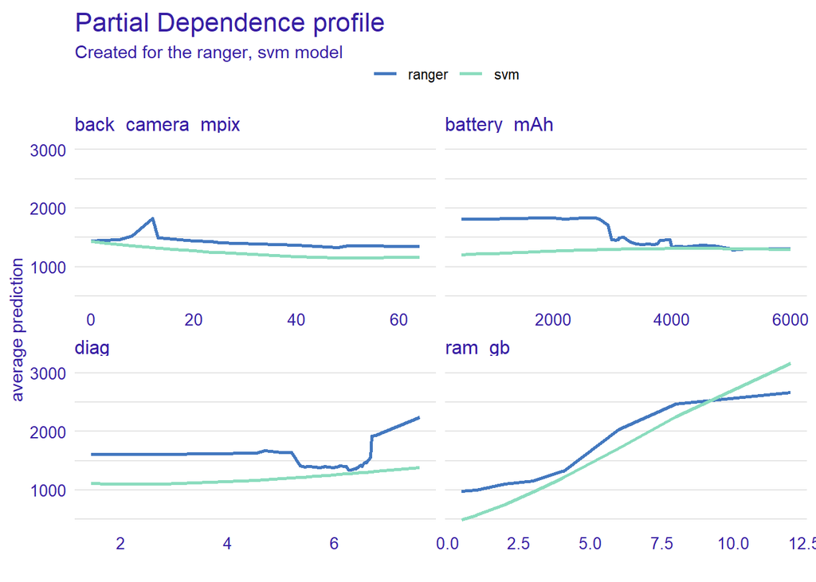

```r
pdp_2 <- model_profile(explainer_ranger, variables=c("back_camera_mpix", "battery_mAh", "ram_gb", "diag"))
pdp_svm_2 <- model_profile(explainer_svm, variables=c("back_camera_mpix", "battery_mAh", "ram_gb", "diag"))

pdp_2$agr_profiles$`_label_` <- "ranger"
pdp_svm_2$agr_profiles$`_label_` <- "svm"
plot(pdp_2, pdp_svm_2)
```

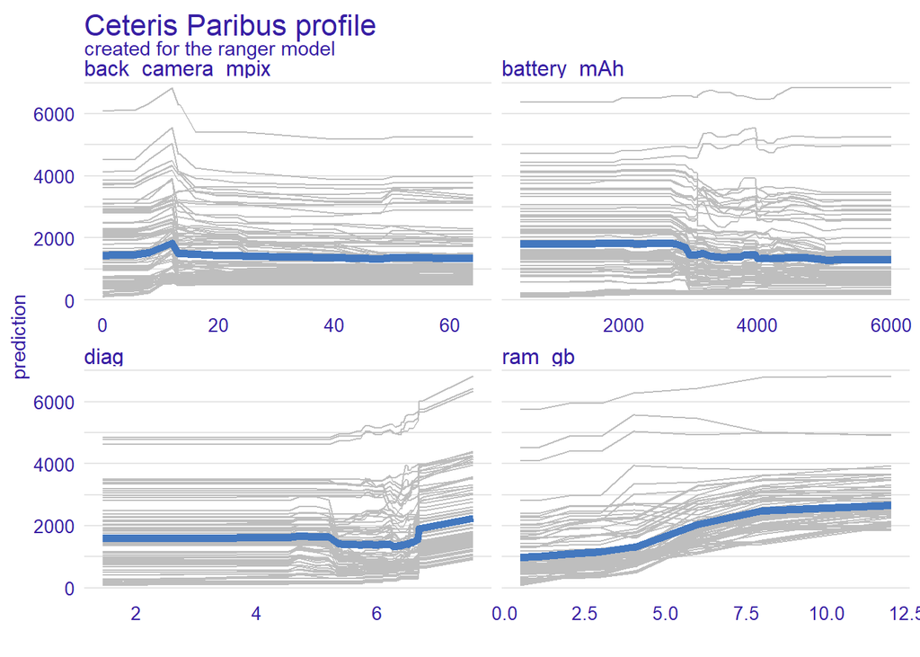

```r
plot(pdp_2, geom = "profiles")
```

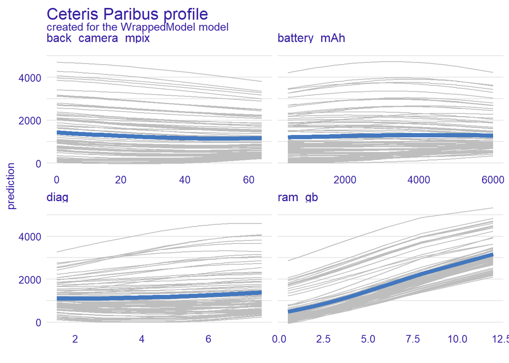

```r
plot(pdp_svm_2, geom = "profiles")
```

Jak widać powyżej PDP dla obu modeli wygląda zupełnie różnie - dla svm nie ma wyraźnich zmian, są one bardzo łagodne, w przeciwieństwie do tych dla rangera. Największe różnice dla pomiędzy modelami można dostrzec pomiędzy wykresami dla *battery_mAH* oraz *diag*. Dla wykresu zbiorczego możemy również zaobserwować, że dla svm wszystkie linie są łagodne, a dla rangera wiele jest jeszcze bardziej zmiennych (pofalowanych, szpiczastych) niż poprzednio.

### Accumulated Local Dependence (ALE)

Poniżej dla wybranych zmiennych z mojego zbioru policzę ALE:

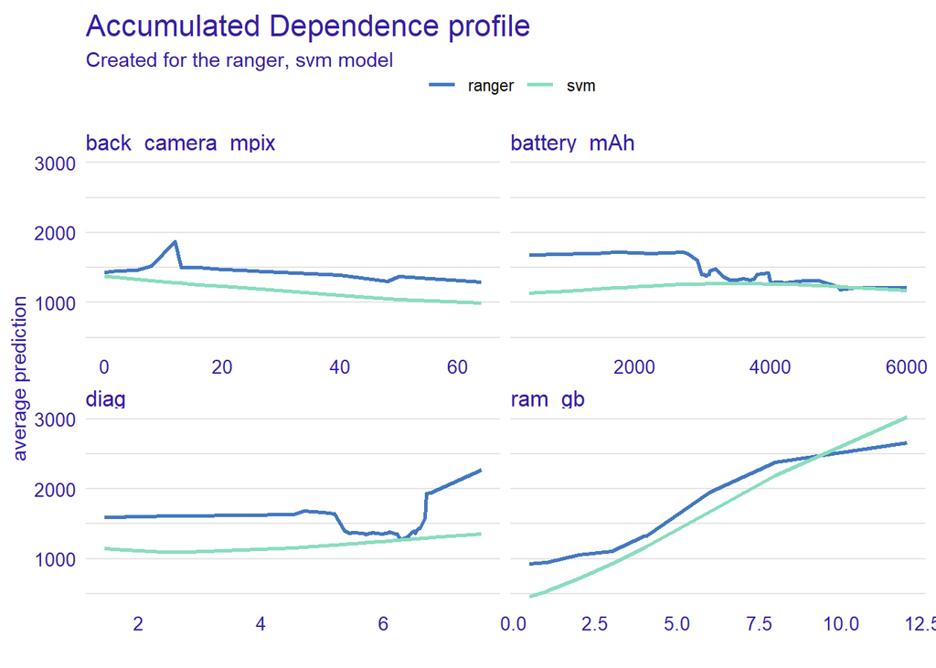

```r
pdp_3 <- model_profile(explainer_ranger, variables=c("back_camera_mpix", "battery_mAh", "ram_gb", "diag"), type = "accumulated")
pdp_svm_3 <- model_profile(explainer_svm, variables=c("back_camera_mpix", "battery_mAh", "ram_gb", "diag"), type = "accumulated")

pdp_3$agr_profiles$`_label_` <- "ranger"
pdp_svm_3$agr_profiles$`_label_` <- "svm"
plot(pdp_3, pdp_svm_3)
```

Powyżej ALE dla rangera i dla SVM. Również widac różnice między modelami.

### Różne kombinacje rozmiaru siatki oraz rozkładu jej punktów. Wpływ na krzywe.

Zobaczmy jak na wybrane z wyżej uzyskanych wyniówi wpłynie zmiana rozmiaru siatki oraz zmiana rozkładu punktów.

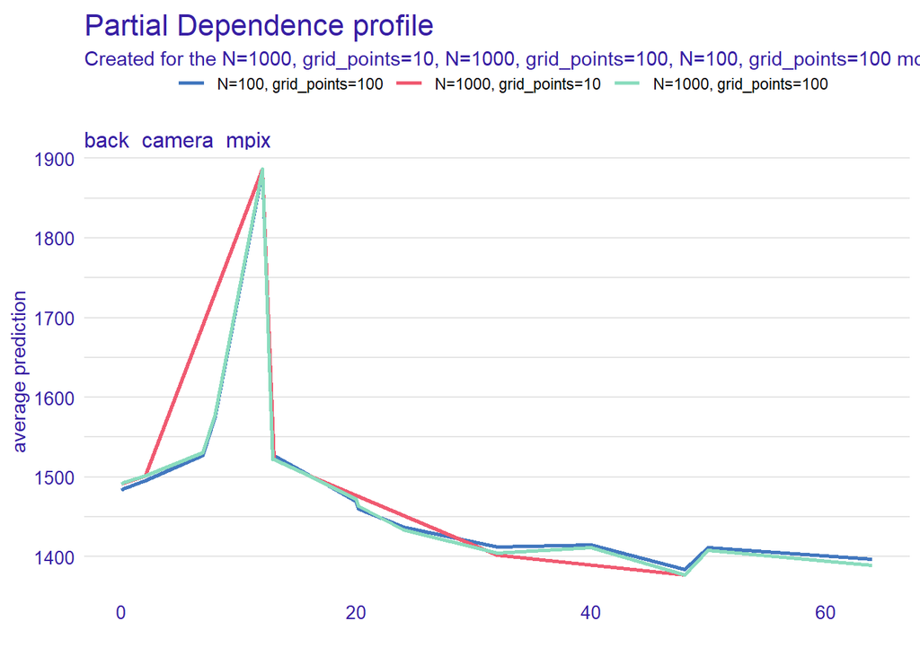

```r
pdp_2_s1 <- model_profile(explainer_ranger, variables="back_camera_mpix", N=1000, grid_points=10)
pdp_2_s2 <- model_profile(explainer_ranger, variables="back_camera_mpix", N=1000, grid_points=100)
pdp_2_s3 <- model_profile(explainer_ranger, variables="back_camera_mpix", N=100, grid_points=100)

pdp_2_s1$agr_profiles$`_label_` <- "N=1000, grid_points=10"
pdp_2_s2$agr_profiles$`_label_` <- "N=1000, grid_points=100"
pdp_2_s3$agr_profiles$`_label_` <- "N=100, grid_points=100"
plot(pdp_2_s1, pdp_2_s2, pdp_2_s3)
```

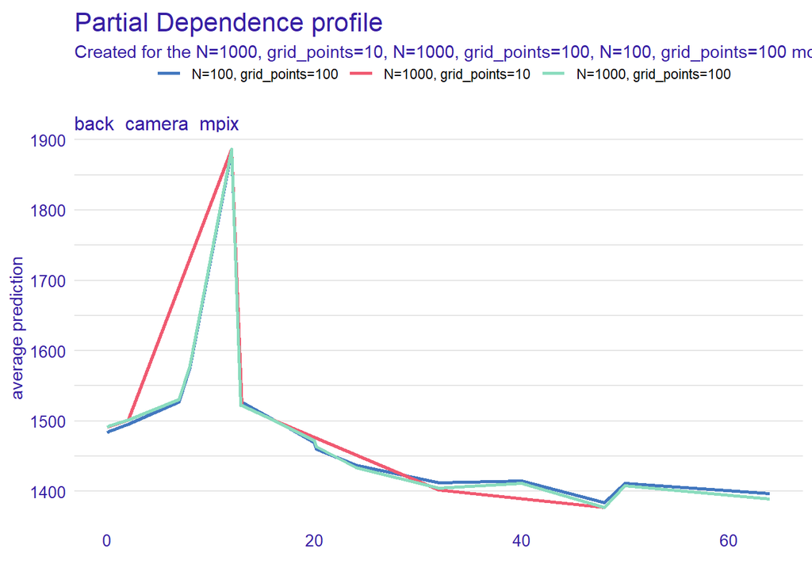

```r
pdp_2_s4 <- model_profile(explainer_svm, variables="back_camera_mpix", N=1000, grid_points=10)
pdp_2_s5 <- model_profile(explainer_svm, variables="back_camera_mpix", N=1000, grid_points=100)
pdp_2_s6 <- model_profile(explainer_svm, variables="back_camera_mpix", N=100, grid_points=100)
pdp_2_s4$agr_profiles$`_label_` <- "N=1000, grid_points=10"
pdp_2_s5$agr_profiles$`_label_` <- "N=1000, grid_points=100"
pdp_2_s6$agr_profiles$`_label_` <- "N=100, grid_points=100"
plot(pdp_2_s1, pdp_2_s2, pdp_2_s3)
```

[output not shown]

### PDP vs ALE

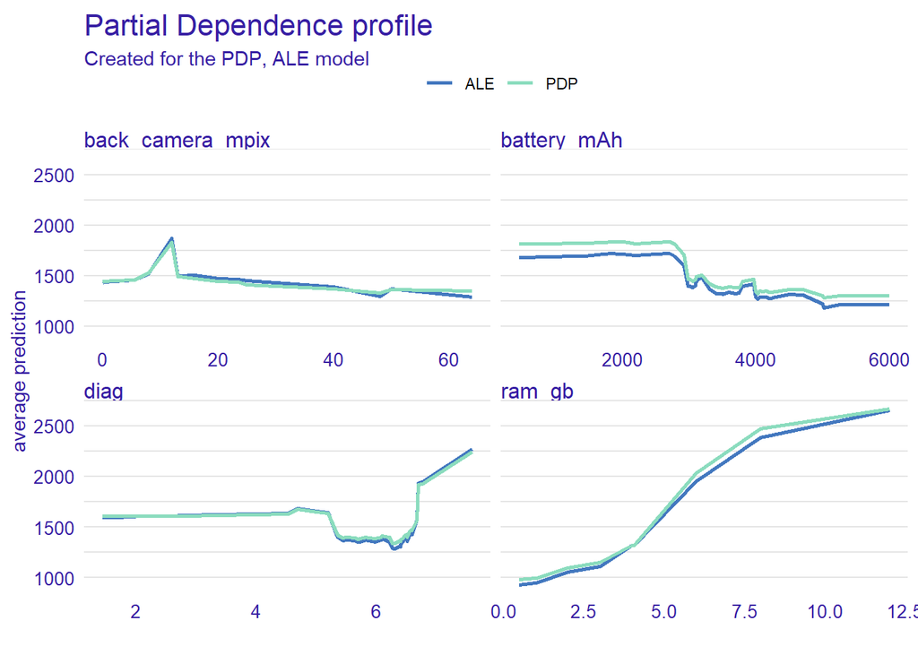

```r
pdp_2$agr_profiles$`_label_` <- "PDP"
pdp_3$agr_profiles$`_label_` <- "ALE"
plot(pdp_2, pdp_3)
```

Wykresu przy użyciu obu funkcji są dość podobne, nieznacznie większą średnią predykcję pokazuje PDP, w szczególności dla *battery_mAh* oraz *ram_gb*.